# MATH3701 - Solution to Chapter 18 Exercises: Parametric Survival Distributions

#### Exercise 18.1

**Part a.** Since $\hat{S}(t)$ is a step function, $t(P)$ is simply the smallest observed event time at which $\hat{S}(t)$ first drops to or below $1-P/100$ – no interpolation needed. For example, for $P=50$ we need $S \le 0.500$: Group I’s $\hat{S}$ drops from $0.545$ at $t=54$ to $0.455 \le 0.500$ at $t=59$, so $t_I(50) = 59$.

| $P$ | Required $S$ | Group I $t(P)$ | Group II $t(P)$ |
| --- | --- | --- | --- |
| 10 | 0.90 | 30 | 54 |
| 20 | 0.80 | 31 | 86 |
| 30 | 0.70 | 44 | 111 |
| 40 | 0.60 | 54 | 152 |
| 50 | 0.50 | 59 | 195 |
| 60 | 0.40 | 88 | 212 |
| 70 | 0.30 | 111 | 212 |
| 80 | 0.20 | 139 | 301 |
| 90 | 0.10 | 149 | 357 |

(At $P=60$ and $P=70$, Group II gives the same value, $212$: the single event there is large enough to drop $\hat{S}$ past both thresholds at once.)

**Part b.** R code:

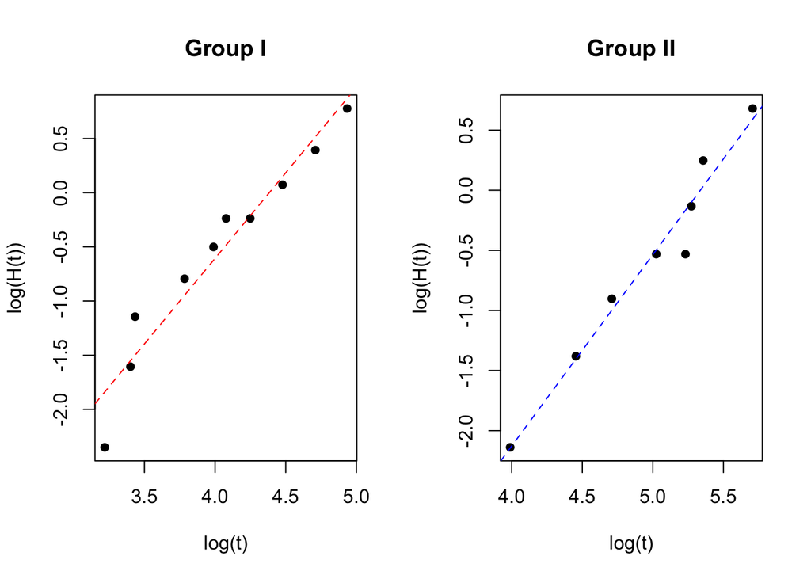

```r
library(survival)

# Group I: 1 censored observation, at t=70
t1 <- c(25, 30, 31, 44, 54, 59, 70, 88, 111, 139, 149)
d1 <- c(1, 1, 1, 1, 1, 1, 0, 1, 1, 1, 1)
km1 <- survfit(Surv(t1, d1) ~ 1)

# Group II: 2 censored observations, at t=25 and t=187
t2 <- c(25, 54, 86, 111, 152, 187, 195, 212, 301, 357)
d2 <- c(0, 1, 1, 1, 1, 0, 1, 1, 1, 1)
km2 <- survfit(Surv(t2, d2) ~ 1)

H1 <- -log(km1$surv)
H2 <- -log(km2$surv)
ok1 <- is.finite(log(H1))
ok2 <- is.finite(log(H2))

par(mfrow = c(1, 2))
plot(log(km1$time)[ok1], log(H1)[ok1], xlab = "log(t)", ylab = "log(H(t))",
     main = "Group I", pch = 16)
abline(lm(log(H1)[ok1] ~ log(km1$time)[ok1]), col = "red", lty = 2)

plot(log(km2$time)[ok2], log(H2)[ok2], xlab = "log(t)", ylab = "log(H(t))",
     main = "Group II", pch = 16)
abline(lm(log(H2)[ok2] ~ log(km2$time)[ok2]), col = "blue", lty = 2)
```

($\log\hat H(t)$ is undefined ($-\infty$ or $\infty$) at $\hat S(t)=1$ or $\hat S(t)=0$ – e.g. Group II’s first point, $t=25$, is censored so $\hat S=1$ there – so these points are dropped via `is.finite()`, exactly as in the worked Weibull-check example earlier in this chapter.)

Both plots show a reasonably straight-line trend, supporting a Weibull model for each group’s survival times.

**Part c.** Fitting a line by eye (or by least squares) to each plot gives approximate slope/intercept pairs:

- **Group I:** slope $\hat\gamma \approx 1.58$, intercept $\log\hat\lambda \approx -6.92$, so $\hat\lambda \approx e^{-6.92} \approx 9.8\times10^{-4}$.
- **Group II:** slope $\hat\gamma \approx 1.59$, intercept $\log\hat\lambda \approx -8.50$, so $\hat\lambda \approx e^{-8.50} \approx 2.0\times10^{-4}$.

The two groups have very similar graphical estimates of $\gamma$ (around 1.6), suggesting a common shape, but Group I’s much larger $\hat\lambda$ indicates a substantially higher hazard than Group II – consistent with Group I’s shorter survival times seen in the percentile table in part (a).

#### Exercise 18.2

**Part a.** R code:

```r
library(survival)

fit1 <- survreg(Surv(t1, d1) ~ 1, dist = "weibull")
fit2 <- survreg(Surv(t2, d2) ~ 1, dist = "weibull")

gamma1_hat <- 1 / fit1$scale
lambda1_hat <- exp(-gamma1_hat * coef(fit1))

gamma2_hat <- 1 / fit2$scale
lambda2_hat <- exp(-gamma2_hat * coef(fit2))

cat("Group I:  gamma =", gamma1_hat, " lambda =", lambda1_hat, "\n")
```

```
## Group I:  gamma = 1.839091  lambda = 0.0002738701
```

```r
cat("Group II: gamma =", gamma2_hat, " lambda =", lambda2_hat, "\n")
```

```
## Group II: gamma = 2.070751  lambda = 1.415195e-05
```

This gives $\hat\gamma_{\text I} \approx 1.84$, $\hat\lambda_{\text I} \approx 2.74\times10^{-4}$, and $\hat\gamma_{\text{II}} \approx 2.07$, $\hat\lambda_{\text{II}} \approx 1.42\times10^{-5}$. These are reasonably close to the graphical estimates from 18.1(c) (which used only the KM jump points visually fitted by eye, so some discrepancy is expected) – both methods agree that $\hat\gamma$ is similar across the two groups (roughly 1.6–2.1) and that $\hat\lambda_{\text I} \gg \hat\lambda_{\text{II}}$.

**Part b.** Since $\hat\gamma_{\text I} \approx 1.84$ and $\hat\gamma_{\text{II}} \approx 2.07$ are fairly close, we can approximate the hazard ratio using the fitted $\hat\lambda$’s:
$$\frac{\hat\lambda_{\text I}}{\hat\lambda_{\text{II}}} =
\frac{2.74\times10^{-4}}{1.42\times10^{-5}} \approx 19.$$
Group I has a hazard roughly **19 times** higher than Group II, i.e. Group I patients experience the event much sooner – consistent with parts (a) and (c) of Exercise 18.1, where Group I’s percentiles were consistently far smaller (shorter survival times) than Group II’s.

### End of Solutions to Exercises 18